# RTMB/corHMM comparisons on rayfinned fish data

Author

Haoyu Ji

Published

February 11, 2026

```r
## corHMM version
## https://github.com/bbolker/corHMM/blob/bolker_clean/misc/test_RTMB.R
## remotes::install_github("bbolker/corHMM", ref = "bolker_clean")
source(here::here("R", "Q_template.R"))
source(here::here("R", "getinfo.R"))
source(here::here("R", "realtree.R"))
```

- In `Q_template.R`, `Q_template()` can be used to generate the transition matrix $Q$, `simfun()` can output trees of arbitrary size and specify the desired trait matrix for generation (currently only supports binary states).
- In `getinfo.R`, `sumfun()` can run corHMM quietly, allowing users to choose between using RTMB or the original version, and extract information (computation time, log-likelihood, and predicted values, etc.).
- `RealTree.R` provides a method for conducting large-scale benchmarking by sampling from real-world datasets.

The dataset is composed of traits + a phylogeny on ray-finned fishes (Eckert et al. 2025)

**import data**

```r
fish_traits <- read.csv(here::here('data', "binaryTraitData.csv"))
fish_tree   <- readRDS(here::here('data', "treeSingle.rds"))
```

**data cleaning**

```r
ctraits <- fish_traits[fish_traits$species %in% fish_tree$tip.label, ]

ctraits <- ctraits[match(fish_tree$tip.label, ctraits$species), ]

c_traits <- data.frame(
  Species = ctraits$species,
  ag = ctraits$ag,
  care = ctraits$care,
  spawning = ctraits$spawning
)

c_traits <- c_traits[!is.na(c_traits$care) & !is.na(c_traits$spawning), ]
c_tree <- drop.tip(fish_tree, setdiff(fish_tree$tip.label, c_traits$Species))

c_traits <- c_traits[match(c_tree$tip.label, c_traits$Species), ]
```

**resampling and running**

```r
ntaxvec <- as.numeric(45:234)

dd <- expand.grid(seed = 101:104, ntaxa  = ntaxvec, ntrait = 3, model = "ARD", rate.cat = 1) |>
  transform(model = as.character(model))

res <- list()

for (i in seq_len(nrow(dd))) {
  cat(sprintf("\rRunning %d/%d", i, nrow(dd)))
  flush.console()

  ntaxa_i <- dd$ntaxa[i]
  sub <- sample_subtree(tree = c_tree, traits = c_traits, ntaxa  = ntaxa_i)

  args_i <- c(
    as.list(dd[i, ]),
    list(
      traitMatrix = sub$traits,
      realtree = sub$tree
    )
  )

  res[[i]] <- do.call(sumfun, args_i)
}

res_df <- do.call(rbind, res)
saveRDS(res_df, file = here::here("data", "trait3_subtree.rds"))
```

**importing rds**

```r
dd <- readRDS(here::here("data", "trait3_subtree.rds"))
if (!is.data.frame(dd)) dd <- as.data.frame(t(dd))
dd$ldiff <- dd$RTMB_loglik - dd$orig_loglik
tt <- t.test(dd$ldiff)
qq <- quantile(dd$ldiff, c(0.25, 0.75))
```

**loglik boxplot**

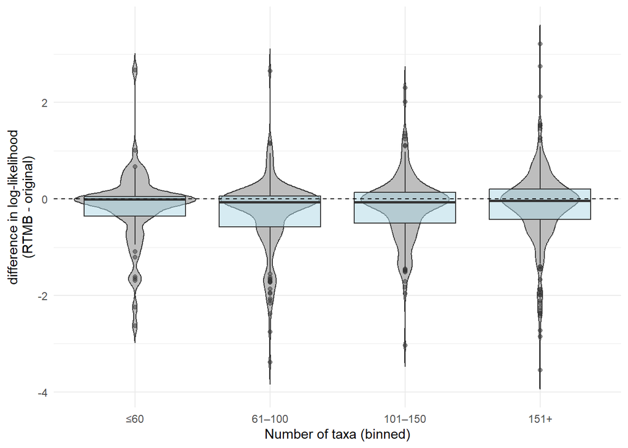

```r
dd$ntaxa_bin <- cut(
  dd$ntaxa,
  breaks = c(0, 60, 100, 150, 250),
  labels = c("≤60", "61–100", "101–150", "151+")
)

ggplot(dd, aes(x = ntaxa_bin, y = ldiff)) +
  geom_violin(fill = "gray", trim = FALSE) +
  geom_boxplot(fill = "lightblue", alpha = 0.5) +
  geom_hline(yintercept = 0, linetype = "dashed") +
  labs(
    x = "Number of taxa (binned)",
    y = "difference in log-likelihood\n(RTMB - original)"
  ) +
  theme_minimal()
```

**basic operations**

```r
ddtb <- dd |>
  transmute(
    seed, ntaxa, ntrait, model,
    ldiff,
    opt_RTMB = RTMB_opt.time,
    opt_orig = orig_opt.time,
    tot_RTMB = RTMB_tot.time,
    tot_orig = orig_tot.time
  ) |>
  pivot_longer(
    cols = c(opt_RTMB, opt_orig, tot_RTMB, tot_orig),
    names_to      = c("type", "method"),
    names_pattern = "(opt|tot)_(RTMB|orig)",
    values_to     = "value"
  ) |>
  mutate(
    type   = factor(type,   levels = c("opt", "tot")),
    method = factor(method, levels = c("orig", "RTMB")),

    good = case_when(
      is.na(ldiff) ~ NA_character_,
      abs(ldiff) < 1e-6 ~ "OK",
      ldiff < 0 ~ "RTMB",
      ldiff > 0 ~ "orig"
    ),
    good = factor(good, levels = c("OK", "orig", "RTMB"))
  )
```

Then check all computing time results.

**visualize time output**

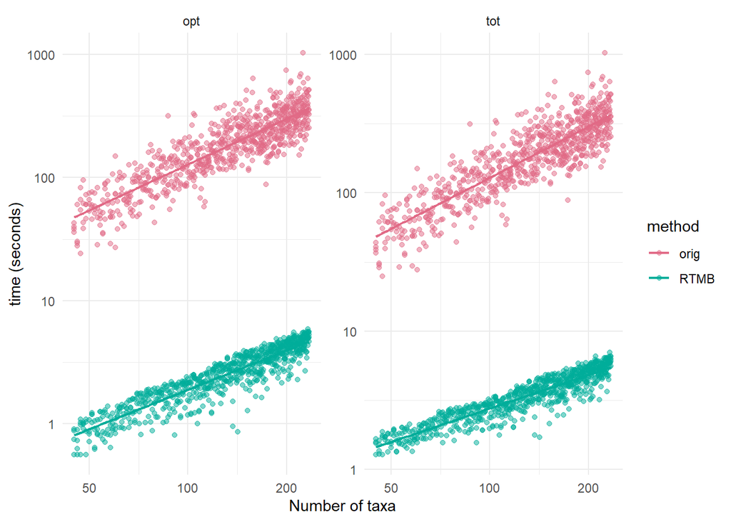

```r
ggplot(ddtb, aes(x = ntaxa, y = value, colour = method)) +
  geom_point(alpha = 0.5) +
  scale_x_log10() +
  scale_y_log10() +
  facet_wrap(~ type, scales = "free_y") +
  geom_smooth(
    method = "lm",
    se = FALSE,
    size = 0.8
  ) +
  labs(
    x = "Number of taxa",
    y = "time (seconds)",
    colour   = "method"
  ) +
    scale_colour_discrete_qualitative() +
  theme_minimal()
```

**reveal in proportion**

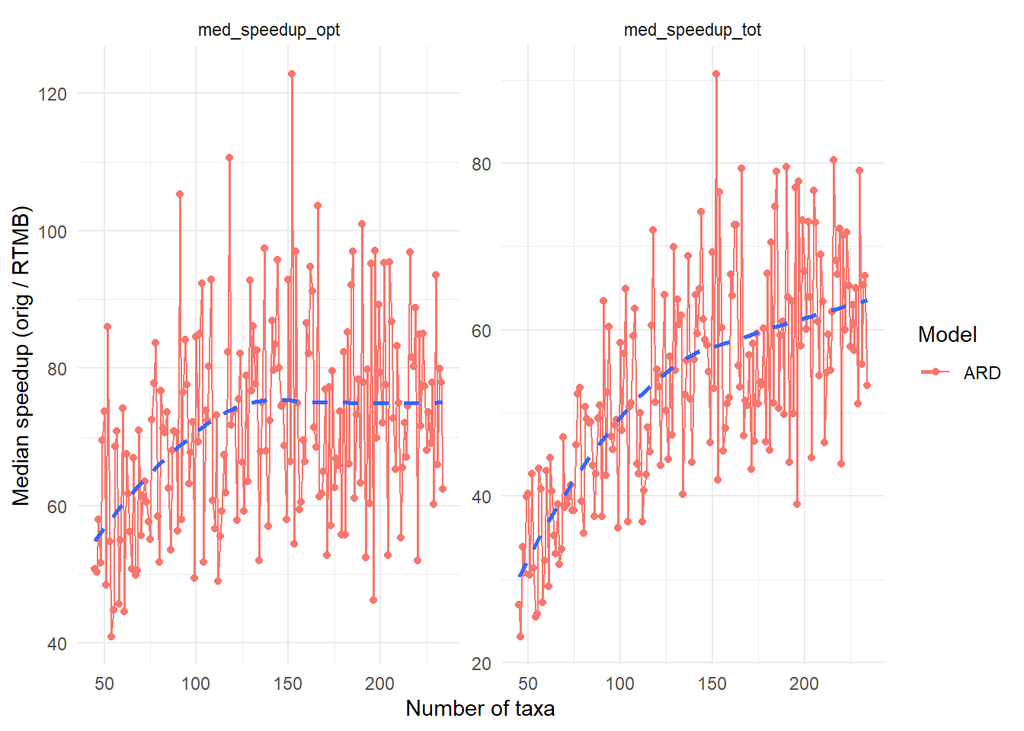

```r
dd$speedup_tot  <- dd$orig_tot.time / dd$RTMB_tot.time
dd$speedup_opt  <- dd$orig_opt.time / dd$RTMB_opt.time

speed_sum <- dd |>
  group_by(ntaxa, model) |>
  summarise(
    med_speedup_tot = median(speedup_tot, na.rm = TRUE),
    med_speedup_opt = median(speedup_opt, na.rm = TRUE),
    .groups = "drop"
  ) |>
  pivot_longer(
    cols = starts_with("med_speedup_"),
    names_to = "type",
    values_to = "med_speedup"
  )

ggplot(speed_sum, aes(x = ntaxa, y = med_speedup, colour = model)) +
  geom_line() +
  geom_point() +
  geom_smooth(
    aes(group = 1, colour = NULL),
    method = "loess",
    se = FALSE,
    linetype = "dashed"
  ) +
  facet_wrap(~ type, scales = "free_y") +
  labs(
    x = "Number of taxa",
    y = "Median speedup (orig / RTMB)",
    colour = "Model"
  ) +
  theme_minimal()
```

Now we plot computation time and negative log likelihood results together. For the same seed and ntaxa, we compare the results from original corHMM and RTMB, and select the result with the smaller NLL (“nll winner”). This result is then put on a scatter plot with ntaxa on the x-axis and comp-time on the y-axis. The size of the point represents the advantage of the nll winner over the other method in that case. Notice that RTMB shows better linearity when there were more nll winners, and this situation goes better when ntaxa increases. This comparison implies RTMB has more stable computational performance.

**nll winner**

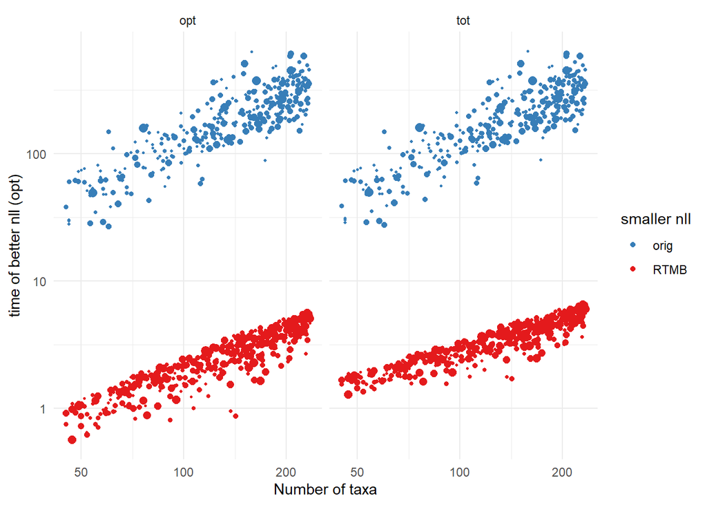

```r
ddtb_win <- bind_rows(
  ddtb |> filter(good %in% c("orig", "RTMB"), as.character(method) == as.character(good))
)
ggplot(
  ddtb_win,
  aes(x = ntaxa, y = value)
) +
  geom_point(aes(colour = good, size = abs(ldiff))) +
  scale_x_log10() +
  scale_y_log10() +
  scale_colour_manual(
    values = c(
      "OK"   = adjustcolor("grey", alpha.f = 0.2),
      "orig" = "#377EB8",
      "RTMB" = "#E41A1C"
    ),
    na.value = "black"
  ) +
  scale_size(range = c(0.5, 3), guide = "none") +
  facet_wrap(~ type, nrow = 1) +
  labs(
    x = "Number of taxa",
    y = "time of better nll (opt)",
    colour = "smaller nll"
  ) +
  theme_minimal()
```

## References

Eckert, Lucas, Jessica S. Miller, John L. Fitzpatrick, Sigal Balshine, and Benjamin M. Bolker. 2025. “Parental Care Drives the Evolution of Male Reproductive Accessory Glands Across Ray-Finned Fishes.” https://dx.doi.org/10.1093/evolut/qpaf062.

Kristensen, Kasper. 2025. *RTMB: ’R’ Bindings for ’TMB’*. https://github.com/kaskr/RTMB.